UCRANIA  
[S.G de Análisis migratorio](https://www.inclusion.gob.es/web/opi/estadisticas)  
05/04/2023

1. Ciudadanos con documentación de residencia en vigor  
2. Otros documentados y estimación de personas sin documentación de residencia  
3. Perfil socio-demográfico y distribución territorial  
4. Afiliación en alta laboral y paro registrado  
5. Nacionalizados españoles por residencia  
6. Solicitantes de Protección Internacional  
7. Beneficiarios del sistema de acogida  
8. Menores no acompañados registrados en el Registro MENAs  
9. Evolución de los flujos regulares (visados y documentación de residencia)  
10. Población española residente en Ucrania

# 1. Ciudadanos con documentación de residencia en vigor

A fecha 30/06/2022 constaban **217.709 ciudadanos de nacionalidad ucraniana con documentación de residencia en vigor en España**:

- 208.310 con Autorización de Régimen General en alguna de las modalidades previstas en la normativa de extranjería española.
- 9.317 con Tarjeta de familiar de ciudadano comunitario en virtud de sus vínculos familiares con algún ciudadano de la UE/AELC.
- 82 con Documento (TIE) del Acuerdo de Retirada como familiar de ciudadano británico beneficiario del acuerdo motivado por el Brexit e iniciado el 6 de julio de 2020.

Nacionales de Ucrania con autorización de residencia según motivo de concesión. 30/06/2022

| Motivo | Personas | % |
| --- | --- | --- |
| TOTAL | 208.310 | 100 |
| Circunstancias excepcionales | 121.623 | 58 |
| Residencia de larga duración | 71.442 | 34 |
| Residencia temporal. Trabajo cuenta ajena | 5.990 | 3 |
| Reagrupación familiar | 2.975 | 1 |
| Residencia temporal no lucrativa | 2.801 | 1 |
| Arraigo | 2.559 | 1 |
| Ley 14/2013 y otras | 606 | 0 |
| Residencia temporal. Trabajo cuenta propia | 309 | 0 |
| Residencia duración determinada. Trabajo cuenta ajena | 5 | 0 |

Fuente: [OPI - SGAM](https://www.inclusion.gob.es/web/opi/estadisticas/catalogo/extranjeros_con_certificado)

Nacionales de Ucrania con tarjeta de familiar de ciudadano comunitario o con TIE de familiar de británico beneficiario del acuerdo de retirada, según motivo. 30/06/2022

| Modalidad | Personas | % |
| --- | --- | --- |
| TOTAL | 9.399 | 100 |
| Familiar No UE. Permanente | 5.273 | 56 |
| Familiar No UE. No permanente | 4.044 | 43 |
| Familiar de británico. Residencia temporal | 51 | 1 |
| Familiar de británico. Residencia permanente | 29 | 0 |
| Titular británico. Residencia temporal | 2 | 0 |

Fuente: [OPI - SGAM](https://www.inclusion.gob.es/web/opi/estadisticas/catalogo/extranjeros_con_certificado)

Nota: La estadística de [Ciudadanos ucranianos en España con documentación de residencia en vigor](https://www.inclusion.gob.es/web/opi/estadisticas/catalogo/ucranianos) (OPI-SGAM) muestra información más detallada.

La comunidad de Ucrania representa un **30% de todos los ciudadanos de Resto de Europa (no UE/AELC) documentados en España.**

Nacionales de Ucrania con documentación de residencia en España según tipo de documentación en vigor y región. 30/06/2022

| Tipo documentación | TOTAL | Nacionales de Resto de Europa (no UE/AELC) | % Resto de Europa (no UE/AELC) respecto Total | Nacionales de Ucrania | % Ucrania respecto Resto de Europa (no UE/AELC) |
| --- | --- | --- | --- | --- | --- |
| TOTAL | 6.246.130 | 733.807 | 11,75 | 217.709 | 29,67 |
| Autorización | 2.520.176 | 293.979 | 11,67 | 208.310 | 70,86 |
| Tarjeta familiar de UE/AELC | 3.530.699 | 247.188 | 7,00 | 9.317 | 3,77 |
| TIE-Acuerdo de retirada | 195.255 | 192.640 | 98,66 | 82 | 0,04 |

Fuente: [OPI - SGAM](https://www.inclusion.gob.es/web/opi/estadisticas/catalogo/extranjeros_con_certificado)

**En la UE, España ocupa el puesto 4 en número de extranjeros documentados de Ucrania**, según datos de Eurostat de finales de 2021.

Nacionales de Ucrania con permiso de residencia en cada país de la UE/AELC según tiempo de validez del permiso. 31/12/2021

| Orden | País UE/AELC | TOTAL | De 3 a 5 meses | De 6 a 11 meses | 1 año o más |
| --- | --- | --- | --- | --- | --- |
| 1 | Polonia | 651.221 | 95.523 | 270.859 | 284.839 |
| 2 | Italia | 230.366 | 29 | 1.330 | 229.007 |
| 3 | República Checa | 193.547 | 341 | 3.162 | 190.044 |
| 4 | España | 97.442 | 55 | 422 | 96.965 |
| 5 | Alemania | 83.043 | 130 | 1.009 | 81.904 |
| 6 | Hungría | 63.175 | 652 | 1.540 | 60.983 |
| 7 | Eslovaquia | 54.138 | 191 | 5.497 | 48.450 |
| 8 | Lituania | 32.884 | 30 | 263 | 32.591 |
| 9 | Portugal | 27.195 | 7 | 139 | 27.049 |
| 10 | Grecia | 20.690 | 0 | 0 | 20.690 |
| 11 | Francia | 18.610 | 293 | 3.182 | 15.135 |
| 12 | Estonia | 14.282 | 3 | 69 | 14.210 |
| 13 | Austria | 9.973 | 12 | 529 | 9.432 |
| 14 | Bulgaria | 9.149 | 45 | 1.124 | 7.980 |
| 15 | Letonia | 9.087 | 38 | 1.184 | 7.865 |
| 16 | Países Bajos | 8.238 | 5 | 171 | 8.062 |
| 17 | Suiza | 7.146 | 91 | 196 | 6.859 |
| 18 | Finlandia * | 5.860 | 236 | 1.590 | 4.034 |
| 19 | Suecia | 5.768 | 150 | 209 | 5.409 |
| 20 | Bélgica | 5.673 | 285 | 0 | 5.388 |
| 21 | Chipre | 4.573 | 74 | 807 | 3.692 |
| 22 | Noruega | 3.135 | 66 | 382 | 2.687 |
| 23 | Eslovenia | 2.655 | 7 | 141 | 2.507 |
| 24 | Croacia | 2.405 | 144 | 1.053 | 1.208 |
| 25 | Rumanía | 2.260 | 9 | 120 | 2.131 |
| 26 | Irlanda | 2.144 | 42 | 487 | 1.615 |
| 27 | Malta | 1.192 | 9 | 157 | 1.026 |
| 28 | Luxemburgo | 997 | 3 | 2 | 992 |
| 29 | Liechtenstein | 76 | 4 | 22 | 50 |
| - | Dinamarca | : | : | : | : |
| - | Islandia | : | : | : | : |

(*) dato de 2020; (:) dato no disponible

Fuente: [Eurostat](https://ec.europa.eu/eurostat/databrowser/view/migr_resvalid/default/table?lang=en)

# 2. Otros documentados y estimación de personas sin documentación de residencia

**Personas con Autorización de Estancia por Estudios**

A 30/06/2022 constaban 319 nacionales de Ucrania documentados con una autorización de estancia por estudios, 35% hombres y 65% mujeres.

| Tipo de solicitante | TOTAL | Hombres | Mujeres |
| --- | --- | --- | --- |
| TOTAL | 319 | 111 | 208 |
| Estudiante | 308 | 103 | 205 |
| Familiar | 11 | 8 | 3 |

Fuente: [OPI - SGAM](https://www.inclusion.gob.es/web/opi/estadisticas/catalogo/extranjeros_estudios)

**Solicitantes de asilo pendientes de resolución**

La información publicada en la web pública de Eurostat indica que, a 28/02/2023 (último dato disponible), había 1.440 personas de nacionalidad ucraniana que tenían pendiente de resolución su solicitud de Protección Internacional.

Fuente: [Eurostat](https://ec.europa.eu/eurostat/databrowser/view/migr_asypenctzm/default/table?lang=en)

**Empadronados y estimación de personas sin documentación de residencia**

A fecha de 01/01/2022, la más reciente con datos publicados para Ucrania, **constaban empadronados 111.443** nacionales de dicho país. Y a fecha de 31/12/2021 documentados como residentes, estudiantes o solicitantes de asilo pendientes de resolución habría un total de 98.910 personas, lo que sugiere que 12.533 personas de nacionalidad ucraniana podrían residir en España en aquel momento sin documentación de extranjería en vigor, el 11,2% del colectivo.

| Documentación | Personas |
| --- | --- |
| Empadronados a 01/01/2022 | 111.443 |
| Con documentación de residencia a 31/12/2021 | 95.470 |
| Con autorización de estancia por estudios a 31/12/2021 | 620 |
| Solicitantes de asilo pendiente de resolución a 31/12/2021 | 2.820 |
| Empadronados sin documentación de residencia en vigor (estimación) | 12.533 |

Fuente: [Padrón Continuo - INE](https://www.ine.es/dyngs/INEbase/es/operacion.htm?c=Estadistica_C&cid=1254736177012&menu=ultiDatos&idp=1254734710990); [OPI - SGAM](https://www.inclusion.gob.es/web/opi/estadisticas/catalogo); [Eurostat](https://ec.europa.eu/eurostat/databrowser/view/migr_asypenctzm/default/table?lang=en)

# 3. Perfil socio-demográfico y distribución territorial

Nacionales de Ucrania con documentación de residencia según sexo y grupo de edad. 30/06/2022

| TOTAL | Hombres | % Hombres | Mujeres | % Mujeres |
| --- | --- | --- | --- | --- |
| 217.709 | 82.736 | 38 | 134.973 | 62 |

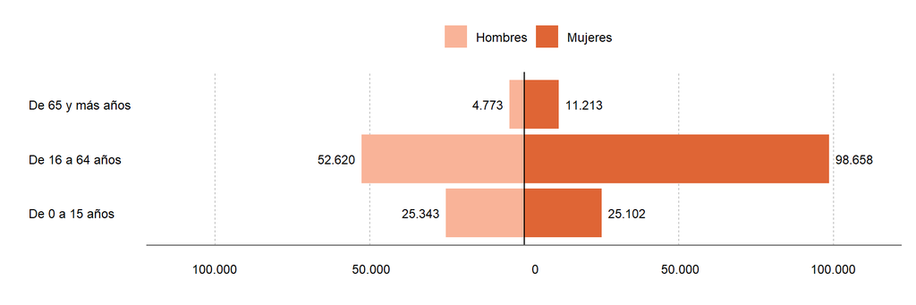

Nacionales de Ucrania con documentación de residencia según provincia de residencia. 30/06/2022

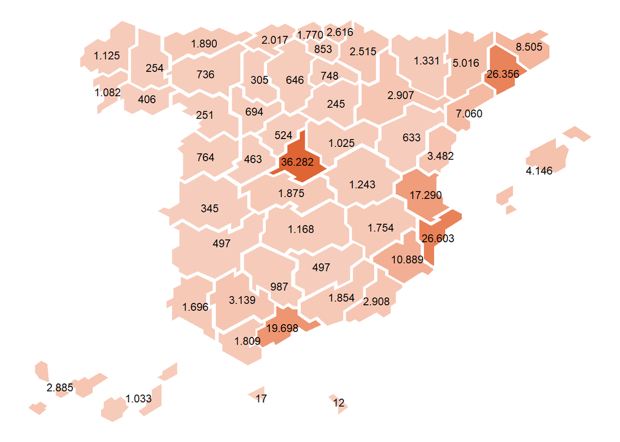

Fuente: [OPI - SGAM](https://www.inclusion.gob.es/web/opi/estadisticas/catalogo/extranjeros_con_certificado)

# 4. Afiliación en alta laboral y paro registrado

**Régimen de afiliación a la Seguridad Social de nacionales de Ucrania a 28/02/2023**

En España hay 60.806 afiliados de Ucrania, que representan un 3,7% del total de ciudadanos de países no UE/AELC en alta laboral. 26.380 (43%) son hombres y 34.426 (57%) mujeres.

| Régimen | Afiliados de Ucrania | Afiliados no UE/AELC | % Ucrania sobre no UE/AELC |
| --- | --- | --- | --- |
| TOTAL | 60.806 | 1.629.683 | 3,7 |
| Régimen General | 42.126 | 108.742 | 38,7 |
| R.G. - S.E. Empleados/as hogar | 9.689 | 12.777 | 75,8 |
| R.E. Autónomos/as | 6.952 | 42.070 | 16,5 |
| R.G. - S.E. Agrario | 2.009 | 2.788 | 72,1 |
| R.E. Mar (cuenta ajena) | 27 | 135 | 20,0 |
| R.E. Mar (cuenta propia) | 2 | 22 | 9,1 |
| R.E. Minería carbón | 1 | 1 | 100,0 |

Afiliados nacionales de Ucrania en alta laboral según régimen y sexo. 28/02/2023

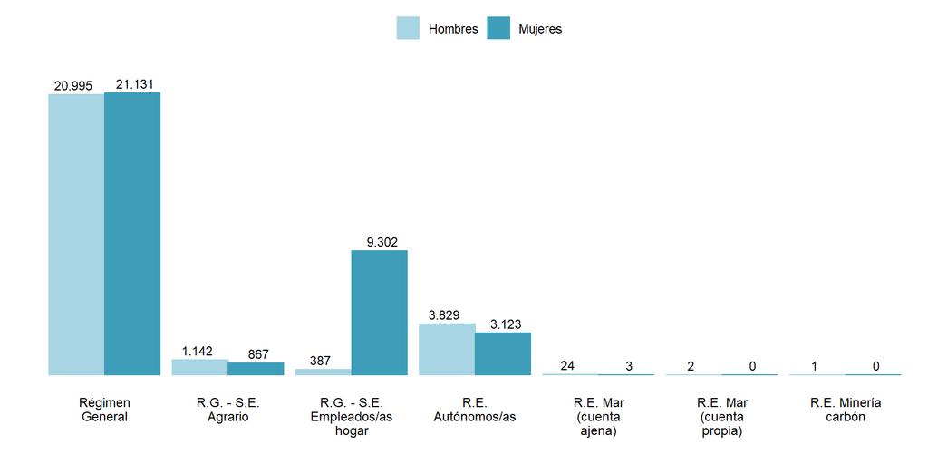

Fuente: [Seguridad Social - MISSM](https://www.seg-social.es/wps/portal/wss/internet/EstadisticasPresupuestosEstudios/Estadisticas/EST8/EST10/EST305/EST307/EST314)

Nota: La estadística de [Ciudadanos ucranianos en España con documentación de residencia en vigor](https://www.inclusion.gob.es/web/opi/estadisticas/catalogo/ucranianos) (OPI-SGAM) muestra información más detallada.

**Parados registrados en el SEPE nacionales de Ucrania (Febrero 2023)**

Hay en España 15.846 parados registrados nacionales de Ucrania, 4.629 (29%) hombres y 11.217 (71%) mujeres.

| TOTAL | Sexo Hombres | Sexo Mujeres | Grupo de edad 16-24 años | Grupo de edad 25-34 años | Grupo de edad 35-44 años | Grupo de edad 45-54 años | Grupo de edad 55 y más años |
| --- | --- | --- | --- | --- | --- | --- | --- |
| 15.846 | 4.629 | 11.217 | 1.025 | 2.769 | 4.914 | 3.677 | 3.461 |
| % | 29 | 71 | 6 | 17 | 31 | 23 | 22 |

Parados registrados en el SEPE nacionales de Ucrania según comunidad autónoma. Febrero 2023

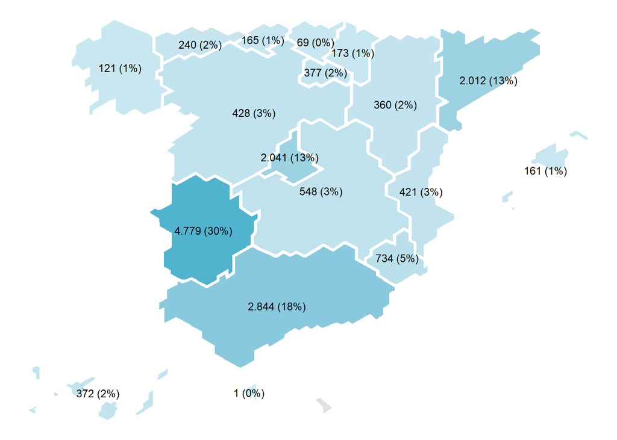

Fuente: [Servicio Público de Empleo Estatal (SEPE)](https://www.sepe.es/HomeSepe/que-es-el-sepe/estadisticas.html)

# 5. Nacionalizados españoles por residencia

**Desde 2009 se han nacionalizado españoles por residencia un total de 14.739 personas con nacionalidad previa ucraniana.**

En 2021 obtuvieron la nacionalidad por residencia 4.270 personas.

Evolución de las concesiones de nacionalidad española por residencia a ciudadanos de Ucrania. 2009─2021

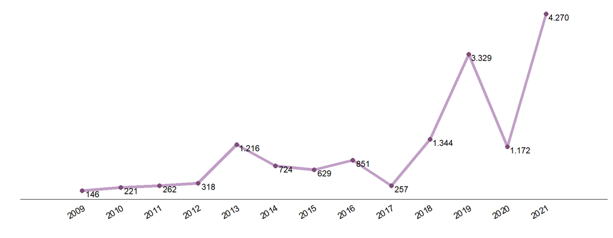

Nota: En 2017 hubo una reducción generalizada de las concesiones de nacionalidad por causas administrativas.

Concesiones de nacionalidad española por residencia a ciudadanos de Ucrania según plazo exigido / motivo. 2021

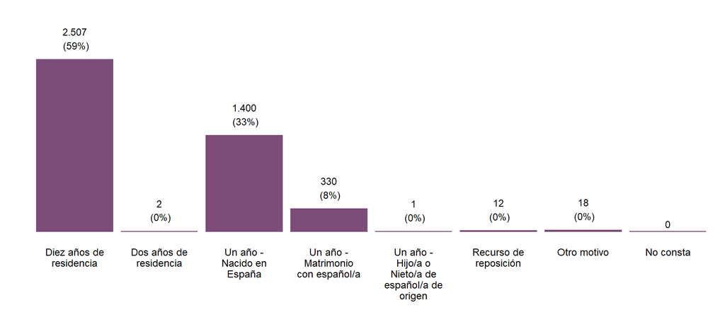

Nota: Existen casos en los que la nacionalidad de origen grabada no coincide con la vía de acceso a la nacionalidad española que debería corresponder según la legislación. Sin embargo, en este momento no se dispone de suficiente información para su correcta depuración.

Concesiones de nacionalidad española por residencia a ciudadanos de Ucrania según sexo y edad. 2021

| TOTAL | Hombres | % Hombres | Mujeres | % Mujeres |
| --- | --- | --- | --- | --- |
| 4.270 | 1.818 | 43 | 2.452 | 57 |

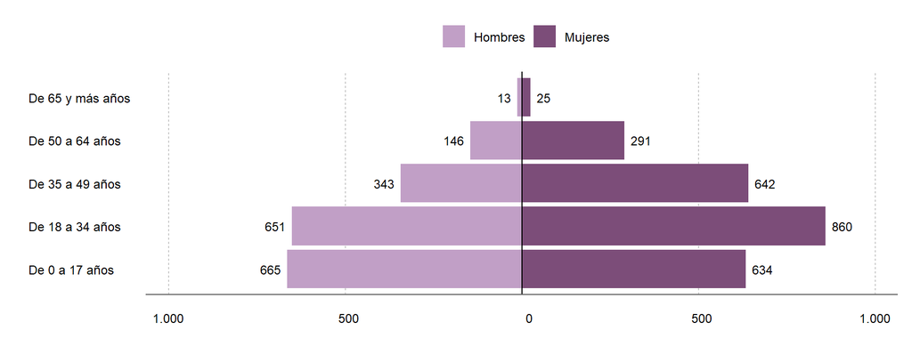

Fuente: [OPI - SGAM](https://www.inclusion.gob.es/web/opi/estadisticas/catalogo/concesiones_nacionalidad)

# 6. Solicitantes de Protección Internacional

**Durante 2022 228 personas nacionales de Ucrania solicitaron Protección Internacional** en el territorio de España, embajadas españolas, puestos fronterizos o CIE. Suponen un 0,2% del total de solicitantes del periodo.

Según avance mensual, **de enero a febrero de 2023 solicitaron Protección Internacional 6 personas con nacionalidad Ucrania**, un 0% del total del periodo.

Evolución de los solicitantes de Protección Internacional nacionales de Ucrania y su distribución según sexo. 2017─2022

(No se han publicado aún datos desagregados por sexo para 2022)

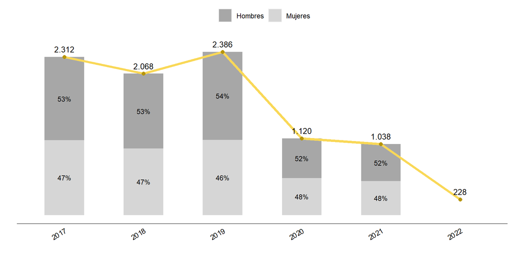

Solicitantes de Protección Internacional nacionales de Ucrania según lugar de presentación de la solicitud. 2021

(No se han publicado aún datos para 2022)

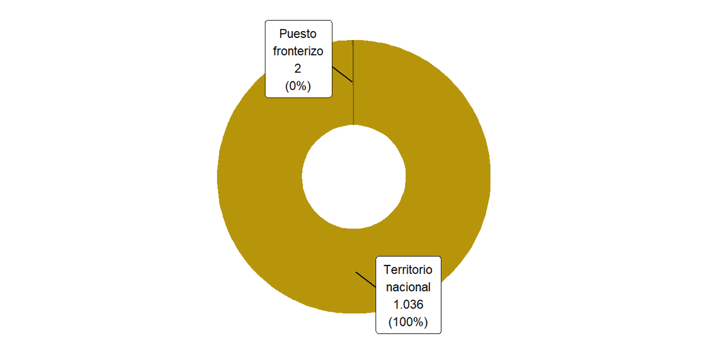

**Durante 2022 se resolvieron 1.512 solicitudes de Protección Internacional de personas con nacionalidad ucraniana.** El 88% fueron favorables.

Evolución de las resoluciones de solicitudes de Protección Internacional de personas nacionales de Ucrania. 2017─2022

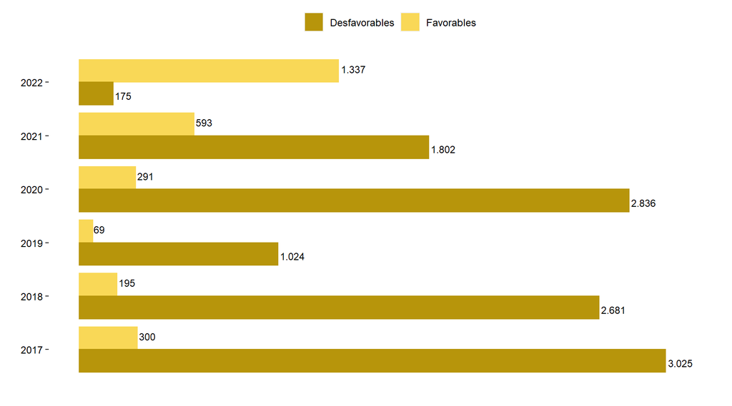

Tipo de resoluciones de solicitudes de Protección Internacional de personas nacionales de Ucrania. 2022

| Resolución | Personas | % |
| --- | --- | --- |
| TOTAL | 1.512 | 100 |
| Reconocimiento condición de refugiado | 26 | 2 |
| Reconocimiento derecho a la protección subsidiaria | 1.311 | 87 |
| Autor. estancia o residencia por razones humanitarias | 0 | 0 |
| Resolución desfavorable | 175 | 12 |

Propuestas de resolución de solicitudes de Protección Internacional de personas nacionales de Ucrania elevadas a la Comisión Interministerial de Asilo y Refugio. Enero─febrero 2023

| Criterio de resolución | Propuestas | % |
| --- | --- | --- |
| TOTAL | 2 | 100 |
| Estatuto de refugiado | 0 | 0 |
| Protección subsidiaria | 2 | 100 |
| Razones humanitarias | 0 | 0 |
| Desfavorables | 0 | 0 |
| Archivo | 0 | 0 |

A raíz de la invasión militar rusa de Ucrania iniciada el 24 de febrero de 2022, el Consejo Europeo activa el 4 de marzo de 2022 la **Directiva de Protección Temporal** a las personas desplazadas. En España, la Protección Temporal es aplicable a:

- Nacionales de Ucrania y sus familiares que residían en Ucrania antes del conflicto.
- Apátridas y nacionales de terceros países con protección internacional en Ucrania antes del conflicto, y sus familiares.
- Apátridas y nacionales de terceros países con residencia legal en Ucrania que no pueden regresar a su país o región, y sus familiares.
- Nacionales de Ucrania en situación de estancia en España antes del conflicto y sus familiares, que, como consecuencia del mismo, no pueden regresar a Ucrania.
- Nacionales de Ucrania que se encontraban en situación irregular en España antes del conflicto y que, como consecuencia del mismo, no pueden regresar a Ucrania.

Evolución de las resoluciones presentadas de Protección Temporal. Marzo 2022 ─ febrero 2023

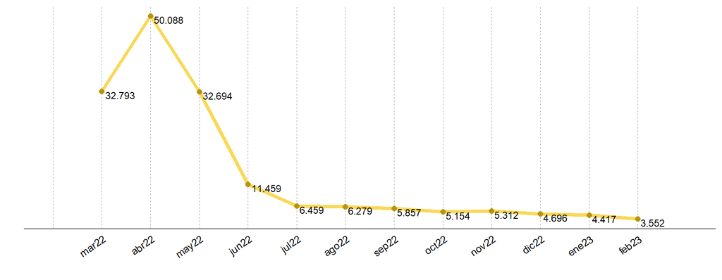

Fuente: [Oficina de Asilo y Refugio - Ministerio del Interior](https://www.interior.gob.es/opencms/es/servicios-al-ciudadano/tramites-y-gestiones/oficina-de-asilo-y-refugio/datos-e-informacion-estadistica/)

# 7. Beneficiarios del sistema de acogida y atención humanitaria

**Actualmente constan 12.916 personas de Ucrania en el Sistema de Acogida para Refugiados, Inmigrantes y Solicitantes de Asilo o en plazas de Atención Humanitaria**; suponen el 42% del total de beneficiarios. 4.332 (34%) hombres y 8.584 (66%) mujeres.

Nacionales de Ucrania beneficiarios del Sistema de Acogida o Atención Humanitaria según sexo y tipo de recurso. 04/04/2023

| Tipo de recurso | TOTAL | Nacionales de Ucrania | % Ucrania respecto Total | Hombres | Mujeres |
| --- | --- | --- | --- | --- | --- |
| TOTAL | 30.723 | 12.916 | 42,0 | 4.332 | 8.584 |
| Atención Humanitaria | 3.628 | 6 | 0,2 | 1 | 5 |
| Protección Internacional - Fase 1 | 17.727 | 5.455 | 30,8 | 1.925 | 3.530 |
| Protección Internacional - Fase 2 | 9.178 | 7.267 | 79,2 | 2.363 | 4.904 |
| Acogida en Familia | 190 | 188 | 98,9 | 43 | 145 |

Nacionales de Ucrania beneficiarios del Sistema de Acogida o Atención Humanitaria según comunidad autónoma de acogida. 04/04/2023

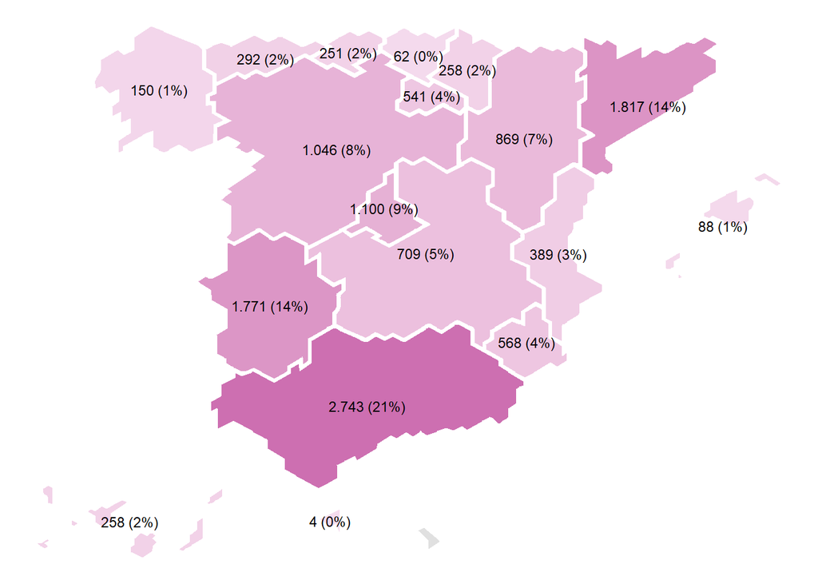

Fuente: SIRIA - MISSM

# 8. Menores no acompañados registrados en el Registro MENAs

**A 28/02/2023, última fecha disponible, había 1.864 menores no acompañados de Ucrania** registrados en el Registro MENAs del Ministerio de Interior, el 19,7% del total. 959 son chicos (51%) y 905 chicas (49%).

La situación de los menores ucranianos es diferente al resto pues se han inscrito en el Registro por un familiar adulto muy cercano, pero que en muchos casos viven al cuidado de familiares o allegados a los que los progenitores han dejado al cuidado. Casi la totalidad del resto de menores de otras nacionalidades están en centros sin ningún referente familiar.

Menores no acompañados de Ucrania según comunidad autónoma de acogida. 28/02/2023

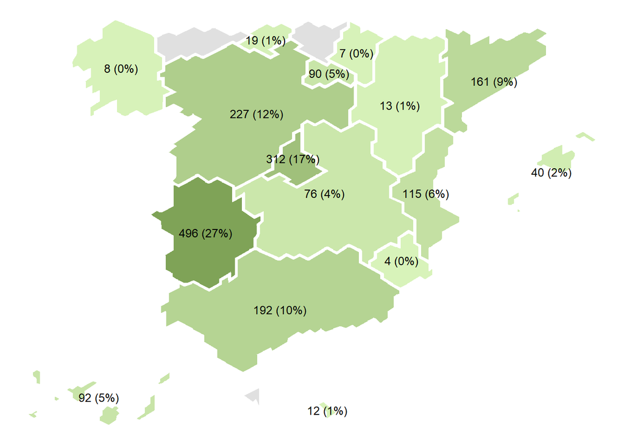

Evolución mensual del registro de menores no acompañados de Ucrania, febrero 2021 ─ febrero 2023

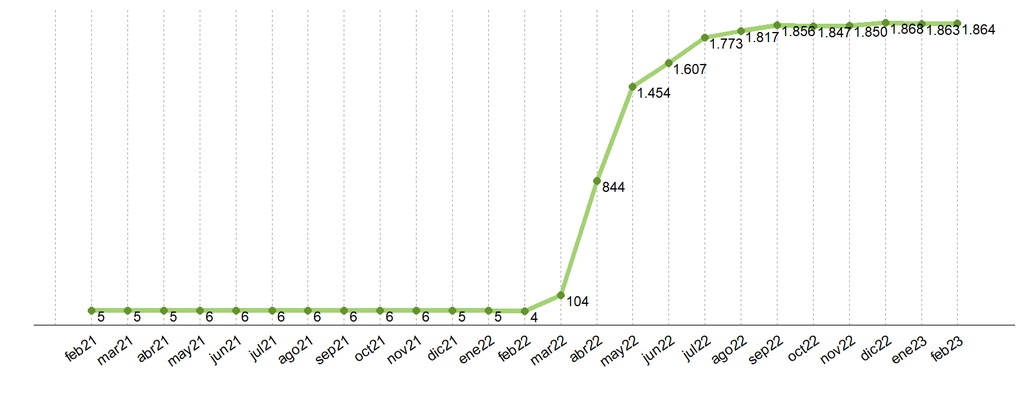

Fuente: Comisaría General de Extranjería y Fronteras - Ministerio del Interior

# 9. Evolución de los flujos regulares (visados y documentación de residencia)

Con respecto al **flujo de visados**, en 2021 se recuperó la movilidad de antes de la pandemia en general para todas las nacionalidades, aunque el número de visados de corta duración se redujo mucho por un cambio normativo de febrero de 2020 en el Código de Visados para las personas que viajan con frecuencia dentro del espacio Schengen, pudiendo entrar un mayor número de veces por más tiempo, reduciéndose el número de visados expedidos de corta duración de múltiples entradas.

Evolución de visados concedidos a ciudadanos de Ucrania según clase de visado. 2012─2021

| Clase | 2012 | 2013 | 2014 | 2015 | 2016 | 2017 | 2018 | 2019 | 2020 | 2021 | % 2021 |
| --- | --- | --- | --- | --- | --- | --- | --- | --- | --- | --- | --- |
| TOTAL | 81.045 | 107.746 | 78.628 | 81.147 | 91.897 | 40.679 | 4.134 | 2.158 | 1.135 | 1.601 | 100 |
| Corta duración | 80.152 | 106.882 | 77.504 | 79.734 | 90.128 | 39.245 | 2.774 | 748 | 88 | 100 | 6 |
| Larga duración | 891 | 864 | 1.122 | 1.413 | 1.769 | 1.434 | 1.359 | 1.410 | 1.047 | 1.501 | 94 |
| Tránsito aeroportuario | 2 | 0 | 2 | 0 | 0 | 0 | 1 | 0 | 0 | 0 | 0 |

Evolución de visados concedidos a ciudadanos de Ucrania según clase de visado de corta o larga duración. 2010─2021

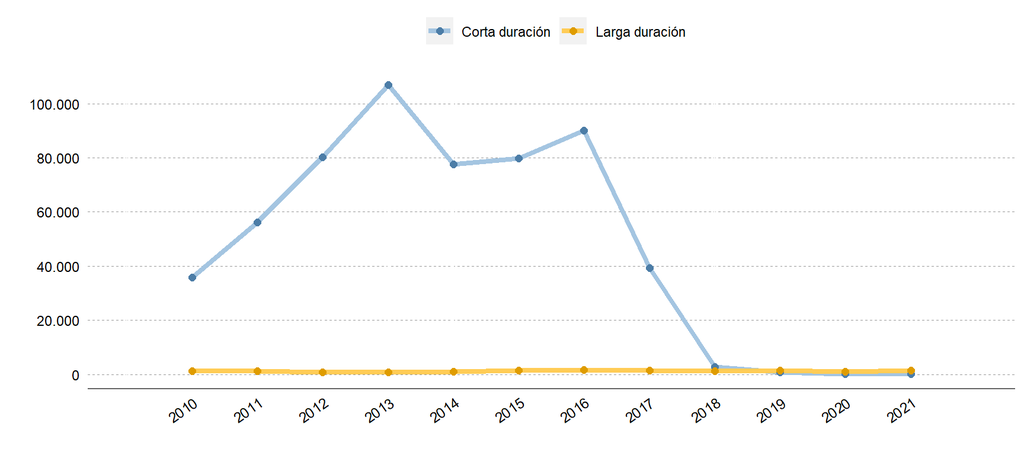

Visados expedidos a nacionales de Ucrania según clase (corta o larga duración) y tipo/finalidad de visado. 2021

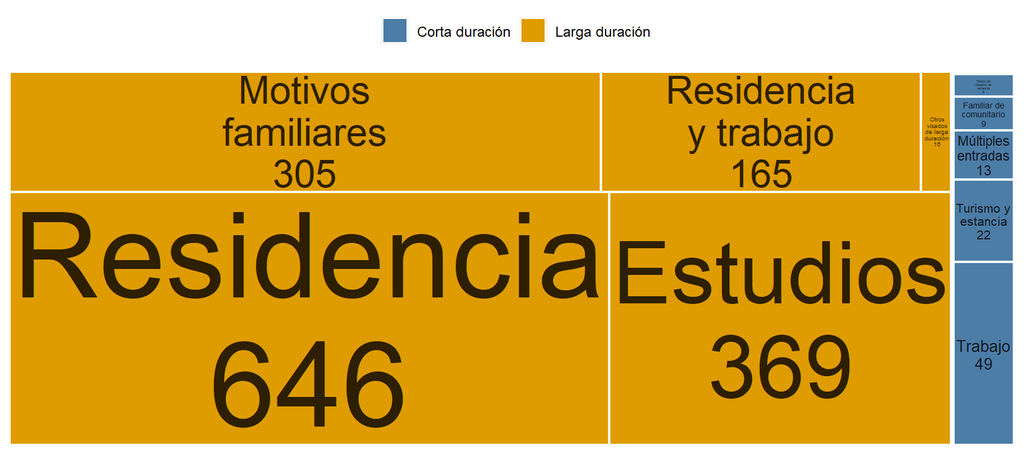

Fuente: [OPI - SGAM](https://www.inclusion.gob.es/web/opi/estadisticas/catalogo/visados)

Los visados de larga duración generalmente dan lugar a documentación de residencia.

En los últimos 5 años se ha expedido **documentación de residencia** (autorizaciones de residencia y tarjetas de familiar de comunitario o de británico) a nacionales de Ucrania por los siguientes motivos:

Autorizaciones de residencia de Régimen General concedidas a ciudadanos de Ucrania según motivo. 2017─2021

| Motivo | 2017 | 2018 | 2019 | 2020 | 2021 |
| --- | --- | --- | --- | --- | --- |
| TOTAL | 7.769 | 9.565 | 10.590 | 9.907 | 11.982 |
| Residencia temporal. Trabajo cuenta ajena | 1.717 | 1.986 | 2.740 | 2.690 | 3.306 |
| Residencia larga duración | 2.510 | 2.570 | 2.249 | 2.234 | 2.290 |
| Residencia temporal no lucrativa | 1.099 | 1.301 | 1.649 | 1.509 | 2.198 |
| Residencia temporal. Circunstancias excepcionales | 1.081 | 2.251 | 2.260 | 1.856 | 2.109 |
| Residencia temporal. Reagrupación familiar | 590 | 587 | 796 | 717 | 1.030 |
| Residencia temporal. Ley 14/2013 y otras | 432 | 546 | 559 | 572 | 733 |
| Residencia temporal. Trabajo cuenta propia | 95 | 107 | 158 | 158 | 167 |
| Residencia larga duración-UE | 157 | 140 | 117 | 101 | 104 |
| Residencia duración determinada. Trabajo cuenta ajena | 63 | 42 | 28 | 36 | 23 |
| Residencia temporal. Excepción a la autorización de trabajo | 15 | 17 | 21 | 17 | 15 |
| Residencia temporal. Compatibilidad cuenta ajena y propia | 10 | 18 | 13 | 17 | 7 |

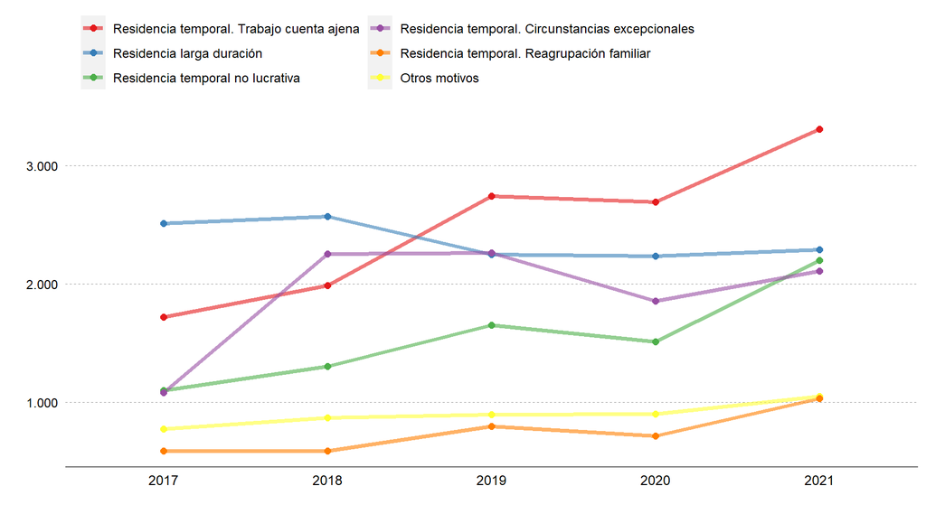

Tarjetas de familiar de ciudadano comunitario y TIE de familiar de británico beneficiario del acuerdo de retirada expedidas a nacionales de Ucrania, según motivo. 2017─2021

| Motivo | 2017 | 2018 | 2019 | 2020 | 2021 |
| --- | --- | --- | --- | --- | --- |
| TOTAL | 1.274 | 1.380 | 1.458 | 1.361 | 1.499 |
| Familiar de UE-RU. Temporal | 803 | 834 | 908 | 814 | 887 |
| Familiar de UE-RU. Permanente | 471 | 546 | 550 | 547 | 612 |

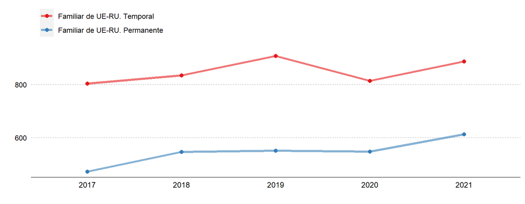

El siguiente gráfico muestra la **distribución de la documentación de residencia (autorizaciones de residencia y tarjetas de familiar de comunitario o de británico) concedida o expedida a nacionales de Ucrania durante 2021, según tipo de trámite**:

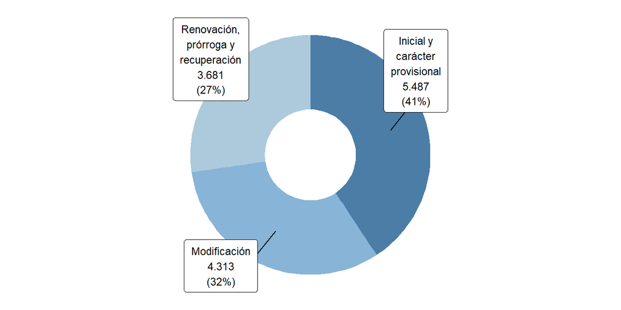

Fuente: [OPI - SGAM](https://www.inclusion.gob.es/web/opi/estadisticas/catalogo/flujo_autorizaciones)

**Comparando con el resto de países de la UE/AELC, el siguiente mapa muestra el número de *primeras* autorizaciones de residencia o de estancia por estudios expedidas a personas de nacionalidad ucraniana durante 2021**, entendiendo como *primera* aquella autorización concedida a una persona si no le fue concedida ninguna otra en los 6 meses anteriores.

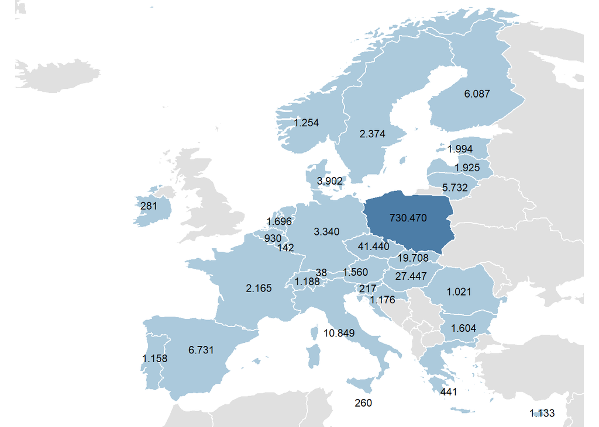

Sin dato disponible: Islandia

Fuente: [Eurostat](https://ec.europa.eu/eurostat/databrowser/view/migr_resfirst/default/table?lang=en)

# 10. Población española residente en Ucrania

**A 01/01/2023, último dato publicado por el INE, había 256 españoles residentes en Ucrania** inscritos en el fichero central del Padrón de españoles residentes en el extranjero (PERE); suponen el 0% de todos los españoles residentes en países de Europa.

| TOTAL | Hombres | % Hombres | Mujeres | % Mujeres |
| --- | --- | --- | --- | --- |
| 256 | 143 | 56 | 113 | 44 |

Evolución de los españoles residentes en Ucrania. 2009─2023

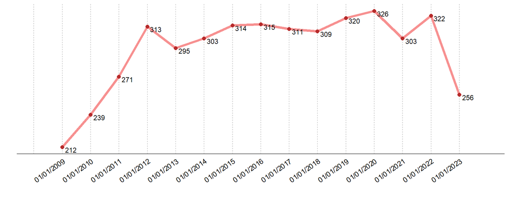

Fuente: [PERE - INE](https://www.ine.es/dyngs/INEbase/operacion.htm?c=Estadistica_C&cid=1254736177014&menu=resultados&secc=1254736195474&idp=1254734710990)